# Part II - (Ford GoBike System Data)

## Dataset Overview

The dataset consists of bicycle trip records (shared from the Ford GoBike System Data) and is described as follows:  
It contains trip information, the time of the trip, the time and date of the start of the trip, the station information, the type of users, the gender of the users, the age of the users, as well as the participation of the users of the information and the bike number.

customer journey duration increases significantly on weekends and Mondays, while subscribers get a slight increase.

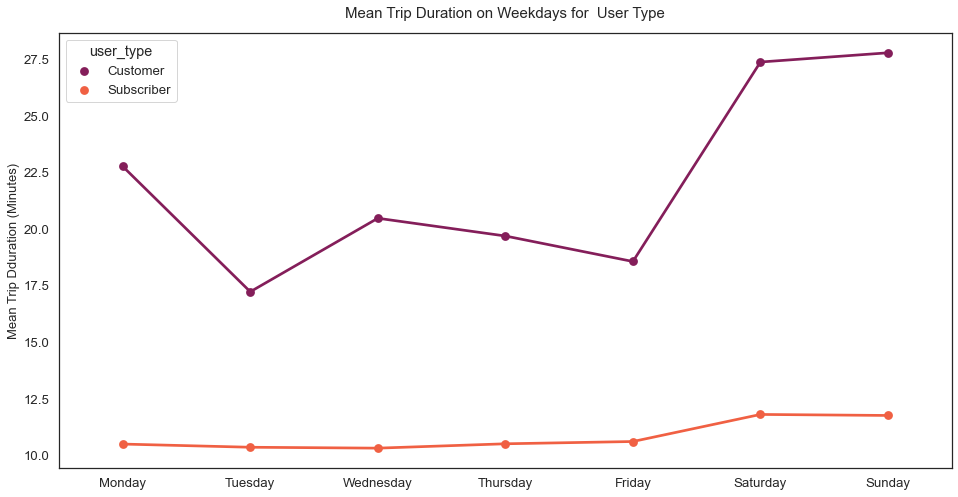

## 2: Mean Trip Duration of the Weekdays with the Member Gender

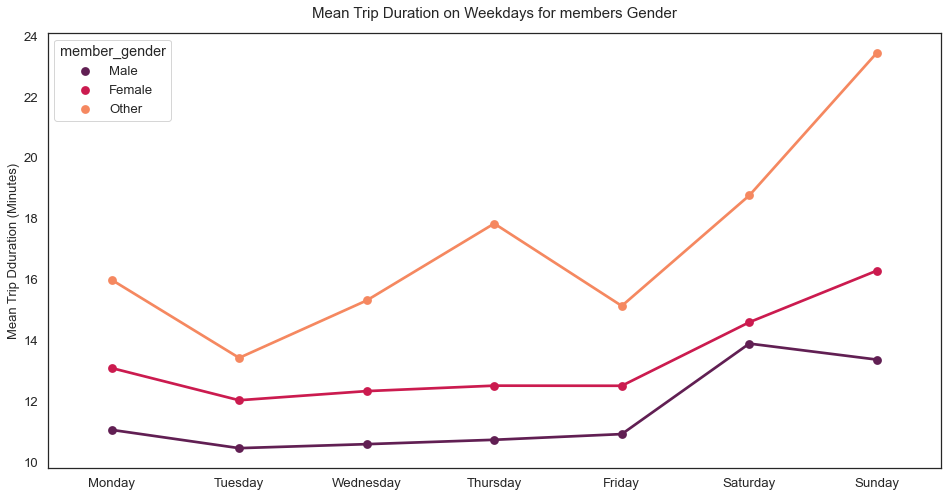

## 3: Mean duration of the trip during the hours of the day with the types of users

Here we clearly see an increase in (Mean trip duration) for customers between 1 and 4 hours, and this is very interesting

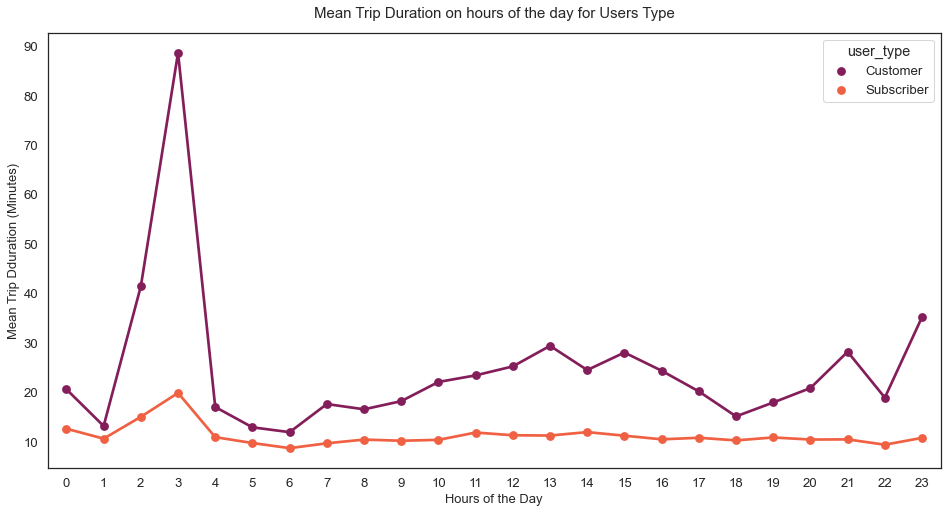

## 4: Mean duration of the trip during the hours of the day with the types of gender

Here we clearly see an increase in (Mean trip duration) for Female and Other between 1 and 4 hours, and this is very interesting

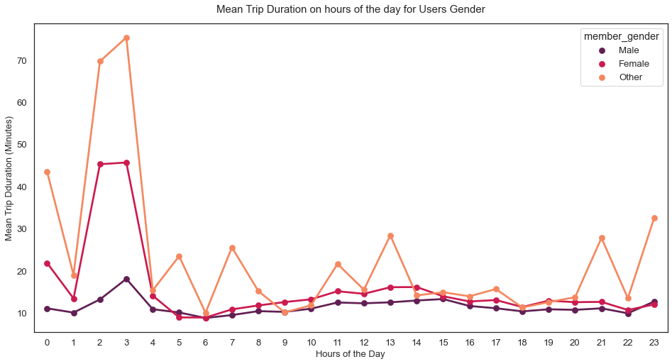